# Анализ употребления арабских заимствований в Новозападноарамейском языке

Автор: Литвинов Ярослав Александрович (МКЛНГ-23)

## Общее описание проекта

Проект представляет собой сопоставительный анализ употребляемых слов в Новом Западноарамейском языке на основании записей и транскрипции устной речи носителей языка. Исследование призвано изучить гипотезу, поставленную явлением языкового сдвига и постепенному переходу от Западноарамейского языка к Арабскому, методами анализа данных

## Сбор данных

В качестве набора данных для исследования был выбран следующий датасет:

[The Maaloula Aramaic Speech Corpus (MASC)](https://zenodo.org/records/6496714)

[figure not shown]

Это датасет для языка Маалулы (Западного Новоармейского, Western Neo-Aramaic) из семитской языковой семьи, в котором содержатся токены и информация про токены, вплоть до возраста и пола говорящего. В настоящее время язык подвергается сильному влиянию арабских заимствований, из-за чего существует языковой сдвиг и угрозы вымирания Маалула.

Исходный датасет был преобразован в таблицу, в которой есть следующие столбцы: 1. Индекс токена 2. Внешний вид (форма) токена 3. Индекс леммы 4. Корень слова 5. Форма цитирования для слова 6. Возраст говорящего 7. Пол говорящего

При составлении данных отталкивались от каждого токена в отдельности, сопоставляя им лемму которой они принадлежат, и подставляя возраст и пол говорящих

### Импорты

```r
library(tidyverse)
```

```r
library(ggplot2)
```

### Данные

```r
aramaic_data <- read.csv("project_data.csv")
```

```r
glimpse(aramaic_data)
```

```
## Rows: 60,601
## Columns: 7
## $ X              <int> 1, 2, 3, 4, 6, 7, 8, 9, 10, 11, 12, 13, 14, 15, 16, 17,…
## $ word_form      <chr> "ana", "ana", "ḥabīb", "fransīs", "maʕlūla", "bann", "n…
## $ lemma_id       <int> 18, 18, 1377, 1978, 241, 12, 86, 74, 10, 1306, 1, 74, 1…
## $ word_root      <chr> "ɁnɁ", "ɁnɁ", "ḥbb", "frnsys", "ʕll", "btt", "ḥky", "Ɂx…
## $ citation_form  <chr> "ana", "ana", "ḥabīb", "fransīs", "maʕlūla", "batt-", "…
## $ speaker_age    <int> 26, 26, 26, 26, 26, 26, 26, 26, 26, 26, 26, 26, 26, 26,…
## $ speaker_gender <chr> "M", "M", "M", "M", "M", "M", "M", "M", "M", "M", "M", …
```

## Гипотеза

Гипотеза, поставленная в этом исследовании, непосредственно исходит от явления языкового сдвига, который происходит в Западноарамейском языке. Арамейские слова постепенно вытесняются арабскими, так как арабский язык все более становится языков образования и общественной жизни, в общем, делает все, что положено делать государственному языку.

Наша гипотеза заключается в том, чтобы проверить, как меняется словоупотребление в зависимости от возраста говорящих. Мы предполагаем, что старые носители языка консервативны и будут использовать арамейские слова. Более молодые же носители, напротив, могут иметь тенденцию к использованию новых, арабских слов.

Таким образом, наши гипотезы можно изложить в следующем виде: H0 - Арабские и Арамейские слова с примерно одинаковой частотой употребляются представителями разных возрастных групп H1 - Арабские и Арамейские слова по-разному употребляются представителями разных возрастных групп Н2 - Употребление Арабских и Арамейских слов обусловлено другими причинами

Чтобы доказать или опровергнуть наше предположение, мы арабские и арамейские слова для сравнения, например: - ʕarḳūba (arkuba) - гора, утес <арабское> - šenna (shenna) - гора, зуб <арамейское>

Иногда у слова более одного синонима и мы будем это учитывать при составлении категорий.

## Код

### Выборка

Сделаем выборку из токенов, в которых есть эти слова:

```r
lemma_data <- read.csv("lemma_etymology.csv")
# Загружаем данные о наших леммах
```

```r
# Из этих данных достаем слова и их этимологию. Делим данные на две таблицы по признаку этимологии слов
aramaic_table <- lemma_data %>%
  filter(etymology == 1)
arabic_table <- lemma_data %>%
  filter(etymology == 2)
```

```r
# Оставляем из этих табличек только слова
aramaic_words <- aramaic_table$word
arabic_words <- arabic_table$word
```

Посчитаем слова, которые у нас получились

```r
print("Всего размечено слов:")
```

```
## [1] "Всего размечено слов:"
```

```r
print(length(aramaic_words)+length(arabic_words))
```

```
## [1] 437
```

```r
print("Из них:")
```

```
## [1] "Из них:"
```

```r
print("Арамейских -")
```

```
## [1] "Арамейских -"
```

```r
length(aramaic_words)
```

```
## [1] 156
```

```r
print("Арабских -")
```

```
## [1] "Арабских -"
```

```r
length(arabic_words)
```

```
## [1] 281
```

Отфильтруем данные и выберем только те наблюдения, которые потребуются нам для наблюдения. Мы вынуждены взять только наблюдения для слов, которые уже были размечены.

```r
aramaic_selected <- aramaic_data %>%
  filter(citation_form %in% aramaic_words | citation_form %in% arabic_words)
```

### Мутация выборки

Немного мутируем наши данные и добавим колонку, означающую категорию слова (word_class). Пусть 1 будет арамейским словом, а 2 - арабским.

```r
aramaic_class <- aramaic_selected %>%
  mutate(word_class = ifelse(citation_form %in% aramaic_words, 1, 2))
```

```r
glimpse(aramaic_class)
```

```
## Rows: 12,142
## Columns: 8
## $ X              <int> 1, 2, 8, 9, 13, 16, 20, 26, 29, 36, 39, 46, 48, 59, 64,…
## $ word_form      <chr> "ana", "ana", "naḥək", "ex", "ex", "anaḥ", "nmiʕčabrill…
## $ lemma_id       <int> 18, 18, 86, 74, 74, 118, 1546, 1353, 1335, 8, 1353, 65,…
## $ word_root      <chr> "ɁnɁ", "ɁnɁ", "ḥky", "Ɂx", "Ɂx", "Ɂnḥ", "ʕbr", "f", "ay…
## $ citation_form  <chr> "ana", "ana", "aḥək yaḥək", "ex/ux", "ex/ux", "anaḥ", "…
## $ speaker_age    <int> 26, 26, 26, 26, 26, 26, 26, 26, 26, 26, 26, 26, 26, 26,…
## $ speaker_gender <chr> "M", "M", "M", "M", "M", "M", "M", "M", "M", "M", "M", …
## $ word_class     <dbl> 1, 1, 2, 1, 1, 1, 2, 2, 1, 1, 2, 1, 1, 1, 1, 1, 1, 1, 1…
```

Проверим, каково примерное распределение возрастов среди людей произносящих слова из корпуса

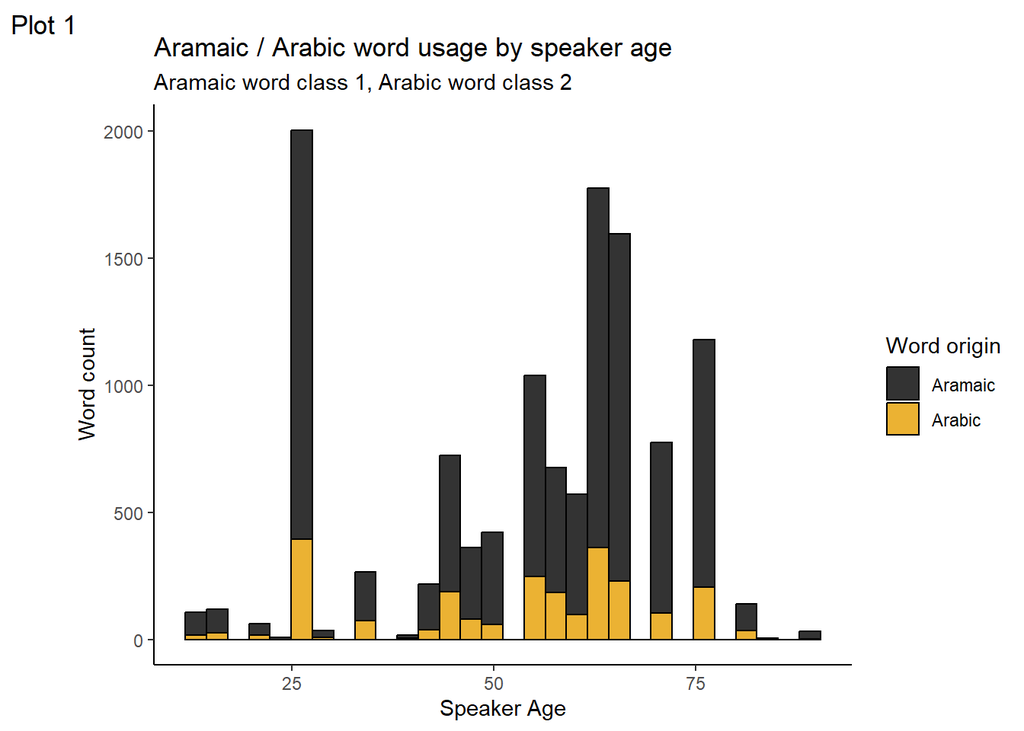

```r
cbbPalette <- c("#000000", "#E69F00", "#56B4E9", "#009E73", "#F0E442", "#0072B2", "#D55E00", "#CC79A7")

aramaic_class %>%
  ggplot(aes(x=speaker_age, group=factor(word_class))) + theme_classic() + geom_histogram(aes(fill=factor(word_class)), alpha=0.8, colour="black") + xlab("Speaker Age") + ylab("Word count") + labs(title="Aramaic / Arabic word usage by speaker age", subtitle=("Aramaic word class 1, Arabic word class 2"), tag="Plot 1") + scale_fill_manual("Word origin", labels=c("Aramaic", "Arabic"), values=cbbPalette)
```

### Проверка гипотезы

```r
wilcox_test <- wilcox.test(speaker_age ~ word_class, data = aramaic_class)
print(wilcox_test)
```

```
##
##  Wilcoxon rank sum test with continuity correction
##
## data:  speaker_age by word_class
## W = 12452230, p-value = 1.358e-07
## alternative hypothesis: true location shift is not equal to 0
```

Исходя из результата теста, то есть, p-value < 5%, мы можем сказать, что наша изначальная нулевая гипотеза вероятно не верна, но судя по другому параметру не можем утверждать этого с полной уверенностью: возможно, слова арабского и арамейского происхождения по-разному используются представителями разных возрастных категорий, но эти различия не столь значительны

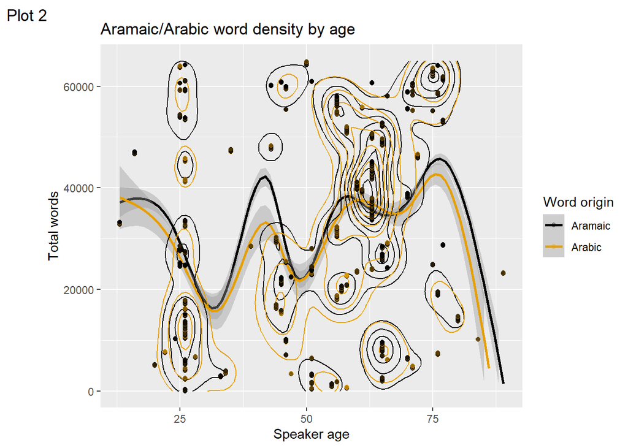

```r
aramaic_class %>%
  ggplot(aes(y=X, x=speaker_age, group=word_class, colour=factor(word_class))) + stat_smooth() + geom_density2d() + geom_point(alpha=0.3) + scale_colour_manual("Word origin", labels=c("Aramaic", "Arabic"), values=cbbPalette) + labs(title="Aramaic/Arabic word density by age", tag="Plot 2") + xlab("Speaker age") + ylab("Total words") + ylim(0, 65000)
```

Кроме того, у нас возникла явная ситуация с неравенством классов. Из стобчатой диаграммы (Plot 1) мы можем наблюдать, что арамейских слов (по крайней мере в числе наших размеченных слов) доминирующее количество

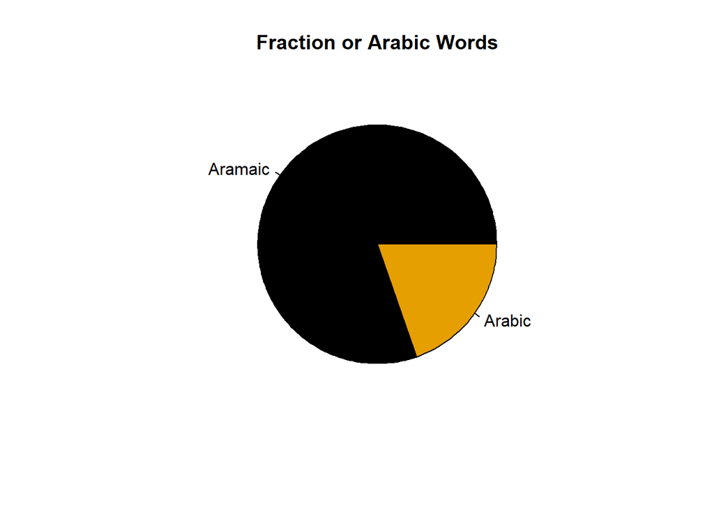

```r
aramaic_table_f <- aramaic_class %>%
  filter(word_class == 1)
aramaic_count <- length(aramaic_table_f$word_class)
arabic_table_f <- aramaic_class %>%
  filter(word_class == 2)
arabic_count <- length(arabic_table_f$word_class)

pie(c(aramaic_count, arabic_count), labels=c("Aramaic", "Arabic"), main="Fraction or Arabic Words", col=c("#000000", "#E69F00"))
```

Вышеуказанные причины создают предпосылки для применения теста Уэлча

```r
spoken_aramaic <- aramaic_class %>%
  filter(word_class == 1)
spoken_aramaic_age <- spoken_aramaic["speaker_age"]
# Получим возрасты всех людей произносящих арамейские слова
spoken_arabic <- aramaic_class %>%
  filter(word_class == 2)
spoken_arabic_age <- spoken_arabic["speaker_age"]
# Сделаем то же самое для арабского

# Проведем t-test
t.test(spoken_aramaic_age, spoken_arabic_age, var.equal = FALSE)
```

```
##
##  Welch Two Sample t-test
##
## data:  spoken_aramaic_age and spoken_arabic_age
## t = 3.8292, df = 3691.2, p-value = 0.0001307
## alternative hypothesis: true difference in means is not equal to 0
## 95 percent confidence interval:
##  0.7238985 2.2429489
## sample estimates:
## mean of x mean of y
##  54.10068  52.61725
```

Тест Уэлча на 95% уверен в том, что различия между возрастом по употреблению слов арамейского и арабского происхождения варьируются в пределах от ~1 до ~2х лет, значит, разница не равна нулю (логично)

Попробуем визуализировать данные другими способами

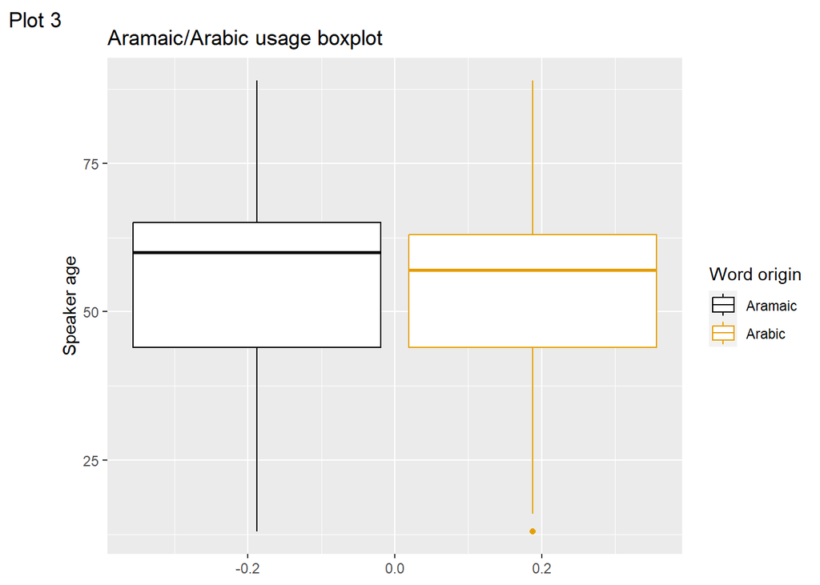

```r
aramaic_class %>%
  ggplot(aes(y=speaker_age, group=word_class, colour=factor(word_class))) + geom_boxplot() + scale_colour_manual("Word origin", labels=c("Aramaic", "Arabic"), values=cbbPalette) + ylab("Speaker age") + labs(title="Aramaic/Arabic usage boxplot", tag="Plot 3")
```

## Выводы

Мы надеемся продолжить работать над разметкой и собрать больше сведений про словоупотребления (употребления токенов в паре с сведениями про леммы и их происхождение, + возраст участников). Так мы сможем получить более объективную картину обнаруженных в этом исследовании зависимостей. Идеальное соотношение можно было бы обнаружить в том случае, если бы размечены были все 3000+ уникальных лемм, входящих в состав MASC. Еще лучше было бы найти другие открытые корпуса текстов на Новом Западноарамейском.